# Homological Algebra

# 40 Lie Algebra Cohomology (Monday, April 19)

## 40.1 Identification of $H^1$ as Derivations

Let ${\mathfrak{g}}\in{\mathsf{Lie}{\hbox{-}}\mathsf{Alg}}_{/k}$ and $M\in{\mathfrak{g}{\hbox{-}}\mathsf{Mod}}$, we were showing
$$\begin{align*}
H^1({\mathfrak{g}}; M) \cong { \mathop{\mathrm{Hom}}_{{\mathfrak{g}{\hbox{-}}\mathsf{Mod}}}( \mathcal{I}, M) \over \operatorname{im}\qty{ \mathop{\mathrm{Hom}}_{{\mathcal{U}(\mathfrak{g}) }}({\mathcal{U}(\mathfrak{g}) }, M) \to \mathop{\mathrm{Hom}}_{{\mathfrak{g}}}( \mathcal{I}, M) } }
,\end{align*}
where the source in the denominator is isomorphic to \(M\), given by the map \(\operatorname{ev}_1\). We found a map
\begin{align*}
\mathop{\mathrm{Hom}}_{\mathfrak{g}}(\mathcal{I}, M) \xrightarrow{\sim} \mathop{\mathrm{Der}}({\mathfrak{g}}, M) \\
\phi \mapsto (D_\phi: x\mapsto \phi(x))
.\end{align*}
We also defined inner derivations as those given by maps \(D_m(x) \mathrel{\vcenter{:}}= mx\) for some \(m\in M\).$$

$$\begin{align*}
H^1({\mathfrak{g}}; M) \cong {\mathop{\mathrm{Der}}({\mathfrak{g}}, M) \over {\operatorname{Inn}}({\mathfrak{g}}, M) }
.\end{align*}$$

In the formula, we already know that the numerator is isomorphic to $\mathop{\mathrm{Der}}({\mathfrak{g}}, M)$, so it remains to look at the denominator. The map appearing there is restriction to $\mathcal{I}$, i.e. $\phi \mapsto { \left.{{\phi}} \right|_{{\mathcal{I}}} }$. The associated derivation is given by
$$\begin{align*}
D_\phi(x) = \phi(x) = \phi(x\cdot 1) = x \phi(1) = xm \mathrel{\vcenter{:}}= D_m(x)
,\end{align*}
and so \(D_\phi = D_m\). Conversely, given an \(m\), we get a derivation \(D_m\), and thus the image is precisely all inner derivations.$$

## 40.2 LHS Spectral Sequences

If ${\mathfrak{h}}{~\trianglelefteq~}{\mathfrak{g}}$, there is a SES in ${\mathsf{Lie}{\hbox{-}}\mathsf{Alg}}$:
$$\begin{align*}
0 \to {\mathfrak{h}}\to {\mathfrak{g}}\to {\mathfrak{g}}/{\mathfrak{h}}\to 0
.\end{align*}$$

Let ${\mathfrak{h}}{~\trianglelefteq~}{\mathfrak{g}}$ and $M\in{\mathfrak{g}{\hbox{-}}\mathsf{Mod}}$, then there are first quadrant spectral sequences
$$\begin{align*}
E_{p, q}^2 &= H_p( {\mathfrak{g}}/{\mathfrak{h}}; H_q({\mathfrak{h}}; M ) ) \Rightarrow H_{p+q}({\mathfrak{g}}; M) \\
E_{p, q}^2 &= H^p( {\mathfrak{g}}/{\mathfrak{h}}; H_q({\mathfrak{h}}; M)) \Rightarrow H^{p+q}({\mathfrak{g}}; M)
.\end{align*}$$

This comes from a similar application of the Grothendieck spectral sequence. The exact sequences in low-degree terms are given as usual[^11] and similar inflation and restriction maps appear here. This is useful because it allows computing homology of “smaller” algebras, which one might have control over by induction.

### 40.2.1 7.7: Chevalley-Eilenberg (Koszul) Complex

A computationally efficient way of compute Lie algebra cohomology using a projective resolution of the trivial ${\mathfrak{g}}{\hbox{-}}$module $k\in{\mathfrak{g}{\hbox{-}}\mathsf{Mod}}$, recalling that this involves acting by zero.[^12]

We’re going to define a chain complex
$$\begin{align*}
V_*({\mathfrak{g}})
\xrightarrow[]{\varepsilon} { \mathrel{\mkern-16mu}\rightarrow }\,
k
,\end{align*}
which will turn out to be supported in finitely many degrees when \(\dim_k {\mathfrak{g}}< \infty\).$$

We’ll assume ${\mathfrak{g}}\in { {\mathsf{Lie}{\hbox{-}}\mathsf{Alg}}_{/k} }(\mathsf{Free})$, which happens e.g. if $k\in \mathsf{Field}$. Recall that the exterior algebra was a graded algebra defined as the quotient of the tensor algebra:
$$\begin{align*}
\bigwedge^* {\mathfrak{g}}\mathrel{\vcenter{:}}={
T({\mathfrak{g}}) \over
\left\langle{x^{\otimes 2} {~\mathrel{\Big|}~}x\in {\mathfrak{g}}
}\right\rangle} = \bigoplus _{p\geq 0} \bigwedge^p {\mathfrak{g}}
.\end{align*}
We write \(x_1\wedge x_2\wedge\cdots \wedge x_p\) for the image of \({\mathfrak{g}}\hookrightarrow\bigwedge^* {\mathfrak{g}}\) Note that this is a 2-sided homogeneous ideal, and since \(x\wedge x = 0\) we have \(x\wedge y = -y\wedge x\).$$

If $\left\{{ x_\alpha }\right\}$ is an ordered basis for ${\mathfrak{g}}$, then there is an ordered basis for $\bigwedge^p {\mathfrak{g}}$:
$$\begin{align*}
\left\{{ { {x_{\alpha}}_1, {x_{\alpha}}_2, \cdots, {x_{\alpha}}_{p}} {~\mathrel{\Big|}~}\alpha_1 < \cdots < \alpha_p }\right\}
,\end{align*}
where we note that the indices are strictly increasing like the sequences \(I\) we had previously. One can always arrange this by commuting things to organize the sequence properly. We also have \(\bigwedge^0 {\mathfrak{g}}\cong k\) with a basis of \(1_k\), and \(\bigwedge^1 {\mathfrak{g}}\cong {\mathfrak{g}}\). In particular, if \(\dim {\mathfrak{g}}= n < \infty\), then \(\bigwedge^p {\mathfrak{g}}= 0\) for all \(p>n\), and in this case \(\bigwedge^n {\mathfrak{g}}\cong k\).$$

Define
$$\begin{align*}
V_p({\mathfrak{g}}) \mathrel{\vcenter{:}}={\mathcal{U}(\mathfrak{g}) }\otimes_k \bigwedge^p{\mathfrak{g}}
,\end{align*}
where the maps are given below.$$

$V_p({\mathfrak{g}})$ is free in $\mathsf{{\mathcal{U}(\mathfrak{g}) }}{\hbox{-}}\mathsf{Mod}$, since we’ve constructed a free basis, and so in particular it is projective. The maps in the complex are given by the following:

[figure not shown]

> Link to Diagram

Here we define
$$\begin{align*}
\theta_1 &\mathrel{\vcenter{:}}=\sum_{i=1}^p ux_i \otimes x_1 \wedge x_2 \wedge \cdots \wedge \widehat{x_i} \wedge \cdots \wedge x_p \\
\theta_2 &\mathrel{\vcenter{:}}=
\sum_{i < j}^p (-1)^{i+j}
u\otimes[x_i x_j] \otimes x_1 \wedge x_2 \wedge \cdots \wedge \widehat{x_i} \wedge \cdots \wedge \widehat{x_j} \wedge \cdots \wedge x_p
,\end{align*}
where the hat denotes omitting a term. Note that \(\operatorname{im}d_1 = {\mathcal{U}(\mathfrak{g}) }\,{\mathfrak{g}}= \mathcal{I} = \ker \varepsilon\), so we get exactness at the first position, and exercise 7.7.1 shows that \(d^2 = 0\).$$

For $p=2$, we have
$$\begin{align*}
d(u\otimes x \otimes y) = \qty{ux\otimes y - uy\otimes x} + \qty{- u \otimes[xy] }
.\end{align*}$$

We want this to be a projective resolution, so not just that $\ker \subset \operatorname{im}$, but rather we want exactness everywhere so $\ker = \operatorname{im}$. We’ll proceed by showing its homology vanishes.

The Koszul complex $V_*({\mathfrak{g}}) \xrightarrow[]{\varepsilon} { \mathrel{\mkern-16mu}\rightarrow }\, k\,$ is a projective resolution in ${\mathfrak{g}{\hbox{-}}\mathsf{Mod}}$.

Choose an ordered basis $\left\{{ e_{ \alpha}}\right\}_{\alpha\in \Omega}$, where $\Omega$ some totally ordered index set, for ${\mathfrak{g}}$ over $k$. By the PBW theorem, $V_n \mathrel{\vcenter{:}}= V_n({\mathfrak{g}})$ has a free $k{\hbox{-}}$basis given by
$$\begin{align*}
\label{basis_elts_pbw_koszul}
e_I \otimes\qty{e_{\alpha_1} \otimes\cdots e_{\alpha_n}}
.\end{align*}
for \(I = [ \beta_1, \cdots, \beta_m ]\) some weakly increasing sequence from \(\Omega\). This gives a filtration, so we’re heading toward using the spectral sequence of a filtered complex. The filtered pieces are given by \(F_p V_n\) defined as the \(k{\hbox{-}}\)module generated by elements of the form given in where \(m+n \leq p\). Looking at the formula for \(d\), we will get a differential
\begin{align*}
d_n F_p V_n \to F_p V_{n-1}
.\end{align*}$$

# 41 Exactness of the Chevalley-Eilenberg Resolution (Wednesday, April 21)

Recall that ${\mathfrak{g}}$ was free over $k$ with an ordered basis $\left\{{ e_{\alpha} {~\mathrel{\Big|}~}\alpha\in \Omega }\right\}$. We defined
$$\begin{align*}
V_n({\mathfrak{g}}) \mathrel{\vcenter{:}}={\mathcal{U}(\mathfrak{g}) }\otimes_k \bigwedge^n {\mathfrak{g}}
\end{align*}
with a differential \(d = \theta_1 + \theta_2\). We claimed that \(V_n({\mathfrak{g}}) \xrightarrow[]{\varepsilon} { \mathrel{\mkern-16mu}\rightarrow }\, k\) is a projective resolution, and we were showing that \(V_*\) was an exact complex.$$

We define a filtration
$$\begin{align*}
F_p V_n \mathrel{\vcenter{:}}= k \left\langle{ e_I \otimes e_{ \alpha_1} \wedge \cdots \wedge e_{\alpha_n} {~\mathrel{\Big|}~}I = [{ {\beta}_1, {\beta}_2, \cdots, {\beta}_{m}}], \alpha_1 \leq \cdots \leq \alpha_n,\, m+n\leq p }\right\rangle
.\end{align*}
Note that \(d: F_p V_n \to F_p V_{n-1}\), and in fact \(\theta_2\) maps into \(F_{p-1} V_{n-1}\). We’ll focus on \(\theta_1\) for simplicity. It lands in the same complex since we can rearrange elements in the sum defining the differential to express everything in terms of the given basis, where every expression will be of length one less. The commutation relation was
\begin{align*}
e_{ \beta} e_{\alpha} = e_{\alpha} e_{\beta} + [e_{\beta} e_{ \alpha} ]
,\end{align*}
where the left-hand side is degree 2, and the right-hand side is a degree 2 term plus a degree 1 term. Moreover \(d\) preserves the filtration: when rearranging, the degree \(u\) term in \(\theta_1\) will decrease to \(m-1\), the expression following it may increase to \(n+1\), and \((m-1) + (n+1) = m+n\). So \(F_p V_*\) is a subcomplex of \(V_*\), and we have
\begin{align*}
0 = F_{-1} V_* \subseteq F_0 V_* \subseteq \cdots \subseteq F_p V_* \subseteq V_* = \bigcup_{p\geq 0} F_p V_*
,\end{align*}
which is not a finite filtration, but is bounded below and exhaustive. So by the canonical convergence theorem (Weibel 5.5.1), there is a convergent spectral sequence
\begin{align*}
E_{p, q}^0 \mathrel{\vcenter{:}}={F_p V_{p+q} \over F_{p-1} V_{p+q} } \Rightarrow H_{p+q}(V_*({\mathfrak{g}}))
.\end{align*}
We have \(E_{p, q}^0 = 0\) unless$$

- $p\geq 0$, since the exterior algebra is only graded in positive degrees.
- $p+q = n \geq 0$
- $q\leq 0$, which requires some explanation. We have $m+n\leq p$, and so if $p+q=n \leq p-m$ for $m\geq 0$, $q\leq -m \leq 0$.

So this is a 4th quadrant spectral sequence that is supported above the line $y=-x$. Recall that $E_{p, q}^1 = H_q^v(E_{p, *}^0)$.

[figure not shown]

> Link to Diagram

Note that
$$\begin{align*}
E_{\infty}^0 \mathrel{\vcenter{:}}= F_0 V_0 / F_{-1} V_0 = k\otimes_k k \cong k
,\end{align*}
since we take expressions with length zero in each factor defining \(F_p V_n\). Moreover this position is already stable provided the \(E_{p, 0}^{1} = 0\) for all \(p\), the first and third quadrants are all zeros, and thus all differentials will be trivial from \(E^1\) onward.$$

For $p>0$, $E_{p, *}^0$ is exact, and thus the spectral sequence collapses at $E^1$.

Note that turning the page yields
$$\begin{align*}
E_{p, q}^1 =
\begin{cases}
k & (p, q) = (0, 0)
\\
0 & \text{else}.
\end{cases}
\end{align*}
Thus \(H_n(V_*({\mathfrak{g}})) = k\) in \(n=0\) and zero elsewhere, which proves the result.$$

For $q\gg 0$, define $A_q \mathrel{\vcenter{:}}= k \left\langle{ e_I {~\mathrel{\Big|}~}I = [{ {\beta}_1, {\beta}_2, \cdots, {\beta}_{q}}] \text{ increasing} }\right\rangle \subseteq {\mathcal{U}(\mathfrak{g}) }$. So $A_q$ is the $q$th graded piece of the standard increasing filtration by degree, \begin{align*} k = U_0 \subset U_1 \subset \cdots \subseteq {\mathcal{U}(\mathfrak{g}) } .\end{align*} Note that this is a section standard filtration of ${\mathcal{U}(\mathfrak{g}) }$ by degree with respect to the PBW basis[^13]. We have $A_q \cong F_q V_0 / F_{q-1} V_0$ and
$$\begin{align*}
E_{p, q}^0 = {F_p V_{p+q} \over F_{p-1} V_{p+q} }
\cong
A_{-q} \otimes_k \bigwedge^{p+q}{\mathfrak{g}}
.\end{align*}
The negative sign is introduced since this is nonzero precisely when \(-p\leq q \leq 0\) so \(q\) is negative and \(-q\) is positive. Now using the definition of \(d: V_n \to V_{n-1}\), \(d^0\) is vertical and
\begin{align*}
d^0: E_{p, q}^0 &\to E_{p, q-1}^0
\quad\quad n = p+q \\ \\
\cong d^0: A_{-1} \otimes_k \bigwedge^n{\mathfrak{g}}&\to A_{-q+1}\otimes_k \bigwedge^{n-1} {\mathfrak{g}}
\quad\quad n = p+q
.\end{align*}$$

Recalling how $d^0$ was defined, note that we’re modding out by lower order terms and thus brackets get killed when we commute elements to order them.

By Weibel 7.3.6, $A \mathrel{\vcenter{:}}=\bigoplus_{q\geq 0} A_q$ is in fact a graded algebra, and $A \cong {\mathsf{gr}\,}{\mathcal{U}(\mathfrak{g}) }$, the associated graded of ${\mathcal{U}(\mathfrak{g}) }$. This turns out to be a polynomial ring on the indeterminates $\mathbf{x} = \left\{{ e_{ \alpha } }\right\}_{\alpha\in \Omega}$, i.e. $A\cong k[\mathbf{x}]$. In Weibel section 4.5, Weibel studies the *Koszul* complex and the map $A \otimes_k \bigwedge^* {\mathfrak{g}}\to A$. By comparing the formula for $d$ between these two complexes, one observes that the Koszul complex differentials are equal to the $d^0$ here. So we have an equality of complexes
$$\begin{align*}
A \otimes_k \bigwedge^* {\mathfrak{g}}= \bigoplus _{p\geq 0} E_{p, *}^0
.\end{align*}
Weibel section 4.5 shows that when \(A\in \mathsf{CRing}\) with no zero divisors, e.g. a polynomial ring, then
\begin{align*}
H_n \qty{ A \otimes_k \bigwedge^* {\mathfrak{g}}} =
\begin{cases}
k & n=0
\\
0 & \text{else}.
\end{cases}
\end{align*}
On the other hand, we have
\begin{align*}
H_n \qty{ A \otimes_k \bigwedge^* {\mathfrak{g}}}
&=
\bigoplus H_{n-p}^v( E_{p, *}^0 ) \hspace{4em} p+q=n \implies q=n-p \\
&= \bigoplus _{p\geq 0} E_{p, n-p}^1
.\end{align*}
But we’ve already shown that \(E_{0, 0}^1 = k\), so all of the other \(E^1\) terms must be zero.$$

See section 4.5 on Koszul complex. We’ll do 7.8 next time.

# 42 Friday, April 23

## 42.1 Applications Chevalley-Eilenberg Complex

Last time: $V_n({\mathfrak{g}}) \mathrel{\vcenter{:}}={\mathcal{U}(\mathfrak{g}) }\otimes_k \bigwedge^n {\mathfrak{g}} \xrightarrow[]{\varepsilon} { \mathrel{\mkern-16mu}\rightarrow }\, k$ is a projective resolution in ${\mathfrak{g}{\hbox{-}}\mathsf{Mod}}$. Note that we can introduce negative signs to easily interchange $\mathsf{{\mathfrak{g}}}{\hbox{-}}\mathsf{Mod}$ and $\mathsf{Mod}{\hbox{-}}\mathsf{{\mathfrak{g}}}$.

Let $M\in \mathsf{Mod}{\hbox{-}}\mathsf{{\mathfrak{g}}}$, then
$$\begin{align*}
H_*({\mathfrak{g}}; M) \cong \operatorname{Tor}_*^{{\mathcal{U}(\mathfrak{g}) }}(M, k)
\end{align*}
is the homology of the following complex:
\begin{align*}
M\otimes_{\mathcal{U}(\mathfrak{g}) }V_*({\mathfrak{g}})
\mathrel{\vcenter{:}}= M \otimes_{\mathcal{U}(\mathfrak{g}) }{\mathcal{U}(\mathfrak{g}) }\otimes_k \bigwedge^* {\mathfrak{g}}
\cong M\otimes_k \bigwedge^* {\mathfrak{g}}
,\end{align*}
where we have a concrete differential \(d\) on \(\bigwedge^* {\mathfrak{g}}\) and we can define \(\partial \mathrel{\vcenter{:}}=\one \otimes d\). If \(M\in \mathsf{{\mathfrak{g}}}{\hbox{-}}\mathsf{Mod})\) (which is more convenient for cohomology), then
\begin{align*}
H^*({\mathfrak{g}}; M) \cong \operatorname{Ext}_{\mathcal{U}(\mathfrak{g}) }(k, M)
\end{align*}
is the cohomology of the cochain complex
\begin{align*}
\mathop{\mathrm{Hom}}_{\mathcal{U}(\mathfrak{g}) }(V_*({\mathfrak{g}}), M)
\mathrel{\vcenter{:}}=\mathop{\mathrm{Hom}}_{{\mathcal{U}(\mathfrak{g}) }}({\mathcal{U}(\mathfrak{g}) }\otimes_k \bigwedge^* {\mathfrak{g}}, M)
\cong \mathop{\mathrm{Hom}}_k(\bigwedge^*{\mathfrak{g}}, M)
.\end{align*}$$

This is very concrete! Standard trick for exterior algebras: any $n{\hbox{-}}$cochain $f\in \mathop{\mathrm{Hom}}_k(\bigwedge^n {\mathfrak{g}}, M)$ can be viewed as an alternating $k{\hbox{-}}$multilinear function $f(x_1, \cdots, x_n): {\mathfrak{g}}\to M$. The cochain differential should increase degree, so we define
$$\begin{align*}
\Theta_1 f({ {x}_1, {x}_2, \cdots, {x}_{n}}) = \sum_{i=1}^{n+1} (-1)^{i+1} x_i \cdot f(x_1, \cdots, \widehat{x_i}, \cdots, x_n)
+ \sum_{i < j} (-1)^{i+1} f( [x_i x_j], x_1, \cdots, \widehat{x_i}, \cdots, \widehat{x_j}, \cdots, x_n)
.\end{align*}
Note that the tor definition has the arguments switched compared to the original definition. This is to set up the tensor cancellation of \(\cdots \otimes_{\mathcal{U}(\mathfrak{g}) }{\mathcal{U}(\mathfrak{g}) }\cdots\). Swapping factors and introducing signs makes this work for left \({\mathfrak{g}}{\hbox{-}}\)modules.$$

If $k$ is a field and $\dim_k {\mathfrak{g}}= n$, then for any $M \in {\mathfrak{g}{\hbox{-}}\mathsf{Mod}}$,
$$\begin{align*}
H^i({\mathfrak{g}}; M) = 0 = H_i({\mathfrak{g}}; M) && \forall i\geq n+1
.\end{align*}$$

This follows from the fact that $\bigwedge^{\geq n+1} {\mathfrak{g}}=0$.

Take ${\mathfrak{g}}= {\mathfrak{sl}}_2({\mathbb{C}})$, then $\dim_{\mathbb{C}}{\mathfrak{g}}= 3$ (4 dimensions and one linear condition). Then $H^i({\mathfrak{g}}; m) = 0$ for all $i > 3$.

## 42.2 Brief Intro to Semisimple Lie Algebras (Weibel 7.8)

Public service section since we won’t have a Lie algebras course next Fall. Semisimples: the most important and interesting classes of Lie algebras! These occur frequently and we can prove a lot about them. We’ll assume ${\mathfrak{g}}$ is a finite dimensional Lie algebra over a field $k$, where we’ll soon assume $\operatorname{ch}(k) = 0$.

A Lie algebra ${\mathfrak{g}}$ is **simple** if it has no ideals other than $0$ and ${\mathfrak{g}}$ and $[{\mathfrak{g}}{\mathfrak{g}}] \neq 0$ (i.e. ${\mathfrak{g}}$ is not abelian).

Recall that ${\mathsf{Lie}{\hbox{-}}\mathsf{Alg}}^{\mathsf{Ab}}\approx {\mathsf{k}{\hbox{-}}\mathsf{Mod}}$ are vector spaces, and so if ${\mathfrak{g}}$ is abelian it automatically has a chain of ideals by just taking vector subspaces. These are closed under brackets since bracketing is zero. So if $\dim_k {\mathfrak{g}}\geq 2$, there are nontrivial ideals, so the abelian condition rules out all 1-dimensional Lie algebras – they’re all abelian by taking a generator, bracketing it with itself, and noting you get zero. So there’s only one 1-dimensional Lie algebra over any field $k$: the abelian one.

The derived algebra $[{\mathfrak{g}}{\mathfrak{g}}] {~\trianglelefteq~}{\mathfrak{g}}$ is a subalgebra and always an ideal, so if ${\mathfrak{g}}$ is simple then $[{\mathfrak{g}}{\mathfrak{g}}] = {\mathfrak{g}}$. So ${\mathfrak{gl}}_n({\mathbb{C}})$ is not simple, since $[{\mathfrak{gl}}_n {\mathfrak{gl}}_n] = {\mathfrak{sl}}_n$ by taking traces.

The vector space sum of any two solvable ideals is again a solvable ideal. Note that this works for products of solvable subgroups $N, H\leq G$ with $N$ normal. Use 2-out-of-3 property for solvable groups and quotient by $N$. By finite-dimensionality, we can find a maximal solvable ideal:

For $\dim_k {\mathfrak{g}}< \infty$, define the **radical** to be $\mathop{\mathrm{rad}}{\mathfrak{g}}\mathrel{\vcenter{:}}=\sum I_j$ be the sum of all solvable ideals $I_j{~\trianglelefteq~}{\mathfrak{g}}$. We say ${\mathfrak{g}}$ is **semisimple** if $\mathop{\mathrm{rad}}{\mathfrak{g}}= 0$.

Simple implies semisimple.

${\mathfrak{g}}/ \mathop{\mathrm{rad}}{\mathfrak{g}}$ is always semisimple.

There shouldn’t be any solvable ideals in this quotient, otherwise you could lift. Next up, our most powerful tool for semisimple Lie algebras:

Recall that for $x\in{\mathfrak{g}}$ we can define $\operatorname{ad}_x \in \mathop{\mathrm{End}}_k({\mathfrak{g}})$ where $\operatorname{ad}_x(y) \mathrel{\vcenter{:}}=[x, y]$. It has a well-defined (and basis-independent) trace, so define the **Killing form**[^14]:

$$\begin{align*}
\kappa(x, y) \mathrel{\vcenter{:}}=\operatorname{Tr}(\operatorname{ad}_x \circ \operatorname{ad}_y) \in k && x,y\in{\mathfrak{g}}
.\end{align*}$$

This is a symmetric bilinear form since traces don’t depend on the order of products. It has another nice property, ${\mathfrak{g}}{\hbox{-}}$invariance:
$$\begin{align*}
\kappa([xy], z] = \kappa(x, [yz])
.\end{align*}$$

Let $\operatorname{ch}(k) = 0$ and $\dim_k {\mathfrak{g}}< \infty$. Then ${\mathfrak{g}}$ is semisimple $\iff \kappa$ is nondegenerate.

Omitted, see Humphreys.

Let $\operatorname{ch}(k) = 0$, then ${\mathfrak{g}}$ is semisimple $\iff {\mathfrak{g}}\cong \bigoplus_{i=1}^r {\mathfrak{g}}_i$ as a direct sum/product of simple ideals, so $[{\mathfrak{g}}_i {\mathfrak{g}}_j] = 0$ for $i\neq j$ and $[{\mathfrak{g}}_i {\mathfrak{g}}_i ] = {\mathfrak{g}}_i$. In particular, every ideal of ${\mathfrak{g}}$ is a sum of sum of certain ${\mathfrak{g}}_i$’s, and ${\mathfrak{g}}= [{\mathfrak{g}}{\mathfrak{g}}]$.

These are like “orthogonal” ideals. So we can study semisimple Lie algebras by just studying simple Lie algebras.

Reminder: if $M\in {\mathfrak{g}{\hbox{-}}\mathsf{Mod}}({ \operatorname{Triv}})$, then any derivation $D \in \mathop{\mathrm{Der}}({\mathfrak{g}}, M)$ satisfies $D([xy]) = 0$ for all $x,y\in {\mathfrak{g}}$. This follows from expanding the Leibniz rule and using trivial modules act by zero. There is an isomorphism
$$\begin{align*}
\mathop{\mathrm{Der}}({\mathfrak{g}}, M) \cong \mathop{\mathrm{Hom}}_{\mathsf{k}{\hbox{-}}\mathsf{Mod}}({\mathfrak{g}}^{\operatorname{ab}}, M) && {\mathfrak{g}}^{\operatorname{ab}}\mathrel{\vcenter{:}}={\mathfrak{g}}/ [{\mathfrak{g}}{\mathfrak{g}}]
.\end{align*}
Recall that \(H^1\) is related to derivations.$$

Let ${\mathfrak{g}}\in {\mathfrak{g}{\hbox{-}}\mathsf{Mod}}({\operatorname{ss}})$ with $\dim_k {\mathfrak{g}}< \infty$, then
$$\begin{align*}
H^1({\mathfrak{g}};k ) = 0 = H_1({\mathfrak{g}}; k)
.\end{align*}$$

Since $[{\mathfrak{g}}{\mathfrak{g}}] = {\mathfrak{g}}$, we have ${\mathfrak{g}}^{\operatorname{ab}}= 0$. By Weibel theorem 7.4.1, one can check that $H_1({\mathfrak{g}}; k) \cong {\mathfrak{g}}^{\operatorname{ab}}= 0$. We also had $\mathop{\mathrm{Der}}({\mathfrak{g}}, k) \twoheadrightarrow H^1({\mathfrak{g}}; k)$ (it was outer derivations), the left-hand side is isomorphic to $\mathop{\mathrm{Hom}}_k({\mathfrak{g}}^{\operatorname{ab}}; k)$.

Let ${\mathfrak{g}}\in {\mathsf{Lie}{\hbox{-}}\mathsf{Alg}}({\operatorname{ss}})$ with $\dim_k {\mathfrak{g}}< \infty$ and $\operatorname{ch}(k) = 0$. Then if $k\neq M$ is a simple ${\mathfrak{g}}{\hbox{-}}$module (where simple means no proper nontrivial ${\mathfrak{g}}{\hbox{-}}$invariant submodules), then
$$\begin{align*}
H^i({\mathfrak{g}}; M) = 0 = H_i({\mathfrak{g}}; M)
.\end{align*}$$

Omitted. This uses the Casimir operator for $M$, which is in the center $Z({\mathcal{U}(\mathfrak{g}) })$.

# 43 Section 7.6 (Wednesday, April 28)

Today: filling in some previous things, including proofs for Whitehead’s second lemma and Levi’s theorem.

Let ${\mathfrak{g}}\in{\mathsf{Lie}{\hbox{-}}\mathsf{Alg}}_{/k}$ for $k\in \mathsf{CRing}$ and let $M\in {\mathsf{k}{\hbox{-}}\mathsf{Mod}}$ viewed as a trivial ${\mathfrak{g}}{\hbox{-}}$ module. An **extension of ${\mathfrak{g}}$ by $M$** is a SES in ${\mathfrak{g}{\hbox{-}}\mathsf{Mod}}$ of the following form:
$$\begin{align*}
0 \to M \xrightarrow{\iota} E \xrightarrow{\pi} {\mathfrak{g}}\to 0
.\end{align*}$$

Given such an extension, thinking of $M \subset E$, $M$ becomes a ${\mathfrak{g}}{\hbox{-}}$module in a natural way: given $m\in M$ and $x\in{\mathfrak{g}}$, choose $\tilde x\in E$ such that $\pi(\tilde x) = x$ and set
$$\begin{align*}
x\cdot m \mathrel{\vcenter{:}}=[\tilde x, m]_E \in M {~\trianglelefteq~}E
,\end{align*}
noting that \(M\) is the kernel of a morphism and thus an ideal. Is this well-defined? If \(\tilde x'\in \pi^{-1}(E)\), we have \(\pi(\tilde x' - \tilde x) = 0\) which implies \(\tilde x' -\tilde x\in \ker \pi = M\) by exactness. So we can write \(\tilde x' = m' + \tilde x\) for some \(m'\in M\), and since \(M\) is abelian and its elements bracket to zero, we have
\begin{align*}
[\tilde x ', m] = [m' + \tilde x, m] = [\tilde x, m]
.\end{align*}$$

The extension problem: given a ${\mathfrak{g}}{\hbox{-}}$module $M$ viewed as an abelian Lie algebra, how many (equivalence classes of) extensions of ${\mathfrak{g}}$ by $M$ are there for which the induced action above agrees with the given action? Here we view equivalence as existence of an isomorphism making the following diagram commute:

[figure not shown]

> Link to Diagram

Write $\operatorname{Ext}_{{\mathsf{Lie}{\hbox{-}}\mathsf{Alg}}}({\mathfrak{g}}, M)$ for the set of equivalence classes of such extensions.

We can form semidirect products $M\rtimes{\mathfrak{g}}$ of Lie algebras in the following way: start with the $k{\hbox{-}}$module $M \times{\mathfrak{g}}$ with bracket
$$\begin{align*}
[(m, x), (n, y)] \mathrel{\vcenter{:}}=(x\cdot n - y\cdot m, [xy]) && m,n\in M,\,\, x,y\in{\mathfrak{g}}
.\end{align*}
One checks that this is anticommutative and satisfies the Jacobi identity. This is a Lie algebra containing \(M \times 0\) as an abelian ideal and \(0 \times{\mathfrak{g}}\) as a subalgebra, which fits into a SES
\begin{align*}
0 \to M \xrightarrow{\iota} M\rtimes{\mathfrak{g}}\xrightarrow{\pi} {\mathfrak{g}}\to 0
.\end{align*}
Moreover, the naturally induced action described previously agrees with this semidirect action. Identifying elements with their inclusions, we have
\begin{align*}
[(0, x), (m, 0)] = (x\cdot m - 0, [0, 0] ) = (x\cdot m, 0)
.\end{align*}
Thus there is always at least one extension, called the split extension. There is a classification:$$

Let $M\in {\mathfrak{g}{\hbox{-}}\mathsf{Mod}}$, then there is a bijection of sets
$$\begin{align*}
\operatorname{Ext}({\mathfrak{g}}, M)
&\rightleftharpoons
H^2({\mathfrak{g}}; M)
\end{align*}$$

Note that the map $\pi$ makes $M$ into an $E{\hbox{-}}$module and makes $M$ into a trivial $M{\hbox{-}}$module. See Weibel for a functorial proof, using the same correspondence between $\operatorname{Ext}_R^1(A, B)$ and extensions of $A$ by $B$. Note that we have an algebra, an ideal, and its quotient, which is precisely the setup for the LHS spectral sequence for cohomology with coefficients in $M$. There was an associated 5-term exact sequence, which contains a **classifying map**
$$\begin{align*}
\mathop{\mathrm{Hom}}_{\mathfrak{g}{\hbox{-}}\mathsf{Mod}}(M, M) &\xrightarrow{d^2} \mathop{\mathrm{Hom}}_{{\mathfrak{g}{\hbox{-}}\mathsf{Mod}}}({\mathfrak{g}}, M) \\
\one_M &\mapsto d^2(\one_M)
.\end{align*}
One checks that this only depends on the equivalence class of extensions, and turns out to be a bijection. Weibel’s proof uses some facts about free Lie algebras that we haven’t discussed yet, so we’ll instead do a slightly more down-to-earth proof from Knapp’s book using the Koszul complex.$$

We’ll need to assume $k\in \mathsf{Field}$. Choose a splitting of the following SES as a $k{\hbox{-}}$vector space:

[figure not shown]

> Link to Diagram

So here $\pi \circ j = \one_{\mathfrak{g}}$. Note that we can use $j(x)$ for our $\tilde x$. From section 7.7, we can characterize $H^2({\mathfrak{g}}; M)$ is a subquotient of $\mathop{\mathrm{Hom}}_k\qty{ \bigwedge^2 {\mathfrak{g}}, M}$, recalling that we canceled a ${\mathcal{U}(\mathfrak{g}) }$ when taking the resolution
$$\begin{align*}
{\mathcal{U}(\mathfrak{g}) }\otimes\bigwedge^* {\mathfrak{g}}
\xrightarrow[]{\varepsilon} { \mathrel{\mkern-16mu}\rightarrow }\,
k
\end{align*}
and applying \(\mathop{\mathrm{Hom}}_k({-}, M)\). Specifically, it is \(\ker \delta / \operatorname{im}\delta\) for the coboundary \(\delta\) from corollary 7.7.3. Recall that we define a hom from an \(n\)th piece of an exterior algebra is equivalence to an alternating \(n{\hbox{-}}\)argument function, and define \(w\in \mathop{\mathrm{Hom}}_k\qty{ \bigwedge^2 {\mathfrak{g}}, M }\) by
\begin{align*}
w(x, y) = [jx, hy]_E - j\qty{ [xy]_M } \in E
,\end{align*}
where we’ll omit parentheses and bracket subscripts immediately. We want to detect if this is in \(M\), so use that \(M = \ker \pi\) and check
\begin{align*}
\pi ([jx, jy] - j[xy])
&= [\pi j x, \pi j y] - \pi j[xy] \\
&= [xy] - [xy] \\
&= 0
,\end{align*}
and so \(w(x, y) \in M\) as needed. We now want to compute \(\delta w\) to compute the action \(x\cdot m \mathrel{\vcenter{:}}=[\tilde x, m]_M\), so take \(\tilde x \mathrel{\vcenter{:}}= j(x)\). Use that \(\delta\) has graded degree \(+1\), so
\begin{align*}
\delta w(x,y,z)
&= x\cdot w(y,z) - y\cdot w(x, z) + z\cdot w(x, y)
\\
&\quad -w([xy], z) + w([xz], y) - w([yz], x)
\\ \\
&=
[jx, [jy, jz]] - [jz, j[yz]]
\\
&\quad - [jy, [jz, jz]] + [jy, j[xz]] \\
&\quad + [jz, [jx, jy]] - [jz, j[xy]] \\
&\quad - [j[xy], jz] + j [[xy], z] \\
&\quad + [j[xz], jy] - j [[xz], y] \\
&\quad - [j[yz], jx] + j [[yz], x]
.\end{align*}$$

There is a lot of cancellation here! Use the Jacobi identity for terms in red, and sign rules to cancel the rest:

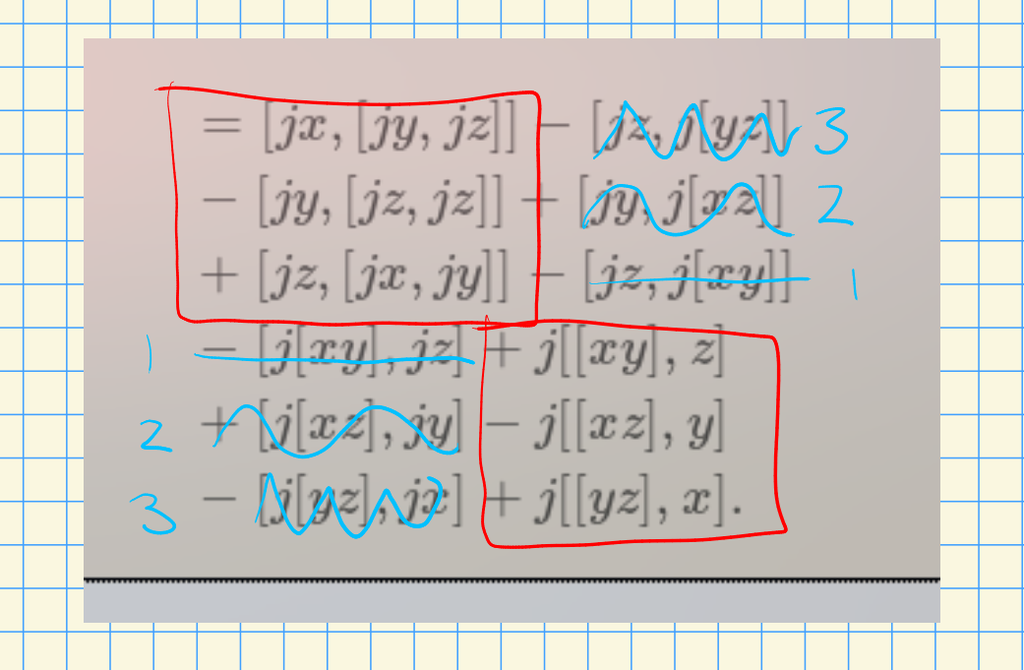

So $w\in \ker \delta$.

> To be continued.

One should check that choices differ by coboundaries, along with a few other things that we’re eliding.

# 44 Friday, April 30

## 44.1 Proof Continued

Last time: we were proving the bijection between $H^2({\mathfrak{g}}; M)$ and extensions of ${\mathfrak{g}}$ by $M$ up to equivalence.

Show that equivalent extensions also lead to the same element in $H^2$.

This yields a well-defined map
$$\begin{align*}
\left\{{ \text{Extensions of ${\mathfrak{g}}$ by $M$ } }\right\} &\to H^2({\mathfrak{g}}; M) \\
(0\to M\to E\to {\mathfrak{g}}\to 0) &\mapsto w
.\end{align*}
Conversely, given a 2-cocycle \(\tilde w\in\mathop{\mathrm{Hom}}_{{\mathsf{k}{\hbox{-}}\mathsf{Mod}}}(\bigwedge^2 {\mathfrak{g}}, M)\) with \(M\) abelian, define$$

- $E \mathrel{\vcenter{:}}= M \oplus {\mathfrak{g}}\in {\mathsf{Vect}}_k$
- A bracket using the following rules (identifying $M, {\mathfrak{g}}$ with their images in $E$):
  - $[m, n]_E \mathrel{\vcenter{:}}= 0$
  - $[x, m]_E \mathrel{\vcenter{:}}= x\cdot m = -[m, x]_E$
    - Note that this guarantees that the actions agree.
  - $[x, y]_E \mathrel{\vcenter{:}}=\tilde w(x, y) + [x, y]_{\mathfrak{g}}$

One can check that the last definition is anticommutative since $w$ was alternating, and further that this makes $E$ into a Lie algebra that fits into a SES of the desired form with canonical maps $i, \pi, j$. The cocycle $w$ coming from this extension is given by
$$\begin{align*}
w(x, y)
&= [x, y]_E - [x, y]_{\mathfrak{g}}\\
&= \tilde w(x, y) + [x, y]_{\mathfrak{g}}- [x, y]_{{\mathfrak{g}}} \\
&= \tilde w(x, y)
\end{align*}
where here \(j\) is a direct sum inclusions that we’ll suppress. So \(H^2 \to \operatorname{Ext}/\sim \to H^2\) is the identity. One can similarly check that \(\operatorname{Ext}/\sim \to H^2 \to \operatorname{Ext}/\sim\) is also the identity, since it produces an equivalent extension. So this defines a bijection of sets.$$

This was known much earlier for group cohomology: if $G \in {\mathsf{Grp}}, A\in {\mathsf{G}{\hbox{-}}\mathsf{Mod}}$, there is a bijection
$$\begin{align*}
\left\{{ 0\to A\to E \xrightarrow{\pi} G \to 1 }\right\}
\mathrel{\vcenter{:}}=
\left\{{ \text{Equivalence classes of extensions of $G$ by $A$ } }\right\}
&\to
H^2(G; A)
,\end{align*}
where \(G\) may not be abelian, and one acts by conjugation instead. Analogy: bracketing is like the differential of conjugation.$$

## 44.2 Proof Backlog from Monday

Recall Whitehead’s Lemma 2[^15] for ${\mathfrak{g}}$ finite-dimensional and semisimple over $\operatorname{ch}(k) = 0$ and $M\in {\mathfrak{g}{\hbox{-}}\mathsf{Mod}}^{\operatorname{fd}}$, then $H^2({\mathfrak{g}}; M) = 0$.

By Weyl’s theorem, $M$ is a direct sum of simple ${\mathfrak{g}}{\hbox{-}}$modules and $H^*$ commutes with direct sums, so it suffices to show this when $M$ is simple. By Weibel theorem 7.8.9 (structure of semisimple Lie algebras using the Casimir operator) we have $H^n({\mathfrak{g}}; M) = 0$ for $M\neq k$ and for all $n$, so we reduce to showing this for $M=k$. By the classification theorem, we need to show that every extension of the following form splits:
$$\begin{align*}
0\to k\to E \xrightarrow{\pi} {\mathfrak{g}}\to 0
,\end{align*}
where we view \(k \in {\mathsf{Lie}{\hbox{-}}\mathsf{Alg}}^{\operatorname{ab}}\). We proceed in an unanticipated way by reducing Lie algebra maps to \({\mathfrak{g}}{\hbox{-}}\)module maps.$$

First note that $k \subset Z{\mathfrak{g}}$, since $E \cong k \oplus {\mathfrak{g}}\in {\mathsf{Vect}}_k$, so there is an embedding ${\mathfrak{g}}\hookrightarrow E$ where say $x\mapsto \tilde x$. For $c\in k$ and $x\in {\mathfrak{g}}$, we have $[\tilde x, c] \mathrel{\vcenter{:}}= x\cdot c = 0$ since $k \in {\mathsf{Lie}{\hbox{-}}\mathsf{Alg}}^{\operatorname{ab}}$, and by linearity this will show that $k$ commutes with everything. We now make $E$ into a ${\mathfrak{g}}{\hbox{-}}$module by defining $x\cdot e \mathrel{\vcenter{:}}=[\tilde x, e]$ for $x\in {\mathfrak{g}}, e\in E$. If $\tilde x'$ is another other representative in $E$ of $x$, then noting that $k \in \ker \pi$ we can write $\tilde x' = [\tilde x + c, e] = [\tilde x, e]$ using that $c\in Z(E)$. This action makes $\pi$ into a ${\mathfrak{g}}{\hbox{-}}$module map, and we have
$$\begin{align*}
\pi(x\cdot e)
&\mathrel{\vcenter{:}}=\pi( [\tilde x, e] ) \\
&= [\pi(\tilde x), \pi(e) ] && \pi \in {\mathsf{Lie}{\hbox{-}}\mathsf{Alg}}({\mathfrak{g}}, E) \\
&\mathrel{\vcenter{:}}=[x, \pi(e)] \\
&\mathrel{\vcenter{:}}= x\cdot \pi(e) \in {\mathfrak{g}}
,\end{align*}
since this is acting via the adjoint action. By Weyl’s theorem, both \(E\) and \({\mathfrak{g}}\) decompose into direct sums of simple \({\mathfrak{g}}{\hbox{-}}\)modules. Using that \(j\) is injective and a \({\mathfrak{g}}{\hbox{-}}\)module map, it must send simple submodules of \({\mathfrak{g}}\) to simple submodules of \(E\), using that maps to (from?) simple modules are either zero or isomorphisms and a dimension count. One can check (easily!) that there is a \({\mathfrak{g}}{\hbox{-}}\)module map \(\sigma: {\mathfrak{g}}\hookrightarrow E\) such that \(E \cong K \oplus \sigma({\mathfrak{g}}) \in {\mathfrak{g}{\hbox{-}}\mathsf{Mod}}\). So choose \(\tilde x \mathrel{\vcenter{:}}=\sigma(x)\), then \(\sigma \in {\mathsf{Lie}{\hbox{-}}\mathsf{Alg}}({\mathfrak{g}}, E)\), and so
\begin{align*}
\sigma( [x, y] )
&\mathrel{\vcenter{:}}= x \cdot \sigma(y) \\
&= [\tilde x, \sigma(y) ] \\
&= [\sigma(x), \sigma(y)]
,\end{align*}
making \(\sigma({\mathfrak{g}}) \leq E\) a Lie-subalgebra. Since \(\sigma({\mathfrak{g}}) \cong {\mathfrak{g}}\), this is precisely a semidirect product and we obtain \(E \cong k \rtimes{\mathfrak{g}}\), and the sequence splits as desired.$$

Next time: Levi’s theorem.

# 45 Appendix: Extra Definitions

# 46 Extra References

- https://www.math.wisc.edu/~csimpson6/notes/2020_spring_homological_algebra/notes.pdf

# 47 Useful Facts

A chain complex $C$ is **acyclic** if and only if $H_*(C) = 0$.

- Free $\implies$ projective $\implies$ flat $\implies$ torsionfree (for finitely-generated $R{\hbox{-}}$modules)
  - Over $R$ a PID: free $\iff$ torsionfree

Notational conventions:

- Finite direct products: $\bigoplus$
- Cohomological indexing: $C^i, {{\partial}}^i$
- Homological indexing: $C_i, {{\partial}}_i$
- Right-derived functors $R^iF$.
  - Come from left-exact functors
  - Require *injective* resolutions
  - Extend to the right: $0 \to F(A) \to F(B) \to F(C) \to L_1 F(A) \cdots$
- Left-derived functors $L_i F$.
  - Come from right-exact functors
  - Require *projective* resolutions
  - Extend to the left: $\cdots L_1F(C) \to F(A) \to F(B) \to F(C) \to 0$
- Colimits:
  - Examples: coproducts, direct limits, cokernels, initial objects, pushouts
  - Commute with left adjoints, i.e. $L(\mathop{\mathrm{colim}}\nolimits F_i) = \mathop{\mathrm{colim}}\nolimits LF_i$.
- Examples of limits:
  - Products, inverse limits, kernels, terminal objects, pullbacks
  - Commute with right adjoints. i.e. $R(\mathop{\mathrm{colim}}\nolimits F_i) = \mathop{\mathrm{colim}}\nolimits RF_i$.

## 47.1 Hom and Ext

- $\mathop{\mathrm{Hom}}_R(A, {-})$ is:
  - Covariant
  - Left-exact
  - Is a functor that sends $f:X\to Y$ to $f_*: \mathop{\mathrm{Hom}}(A, X) \to \mathop{\mathrm{Hom}}(A, Y)$ given by $f_*(h) = f\circ h$.
  - Has right-derived functors $\operatorname{Ext}^i_R(A, B) \mathrel{\vcenter{:}}= R^i \mathop{\mathrm{Hom}}_R(A, {-})(B)$ computed using *injective* resolutions.
- $\mathop{\mathrm{Hom}}_R({-}, B)$ is:
  - Contravariant
  - Right-exact
  - Is a functor that sends $f:X\to Y$ to $f^*: \mathop{\mathrm{Hom}}(Y, B) \to \mathop{\mathrm{Hom}}(X, B)$ given by $f^*(h) = h\circ f$.
  - Has left-derived functors $\operatorname{Ext}^i_R(A, B) \mathrel{\vcenter{:}}= L_i \mathop{\mathrm{Hom}}_R({-}, B)(A)$ computed using *projective* resolutions.
- For $N \in (\mathsf{R}, \mathsf{S'}){\hbox{-}}\mathsf{biMod}$ and $M\in (\mathsf{R}, \mathsf{S}){\hbox{-}}\mathsf{biMod}$, $\mathop{\mathrm{Hom}}_R(M, N) \in (\mathsf{S}, \mathsf{S'}){\hbox{-}}\mathsf{biMod}$.
  - Mnemonic: the slots of $\mathop{\mathrm{Hom}}_R$ use up a left $R{\hbox{-}}$action. In the first slot, the right $S{\hbox{-}}$action on $M$ becomes a left $S{\hbox{-}}$action on Hom. In the second slot, the right $S'{\hbox{-}}$action on $N$ becomes a right $S'{\hbox{-}}$action on Hom.
- $\operatorname{Ext}^{>1}(A, B) = 0$ for any $A$ projective or $B$ injective.

A maps $A \xrightarrow{f} B$ in ${\mathsf{R}{\hbox{-}}\mathsf{Mod}}$ is injective if and only if $f(a) = 0_B \implies a = 0_A$. Monomorphisms are injective maps in ${\mathsf{R}{\hbox{-}}\mathsf{Mod}}$.

Write $F({-}) \mathrel{\vcenter{:}}=\mathop{\mathrm{Hom}}_R(A, {-})$. This is left-exact and thus has right-derived functors $\operatorname{Ext}^i_R(A, B) \mathrel{\vcenter{:}}= R^iF(B)$. To compute this:

- Take an *injective* resolution:
  $$\begin{align*}
  1 \to B \xrightarrow{\varepsilon} I^0 \xrightarrow{d^0} I^1 \xrightarrow{d^1} \cdots
  .\end{align*}$$
- Remove the augmentation $\varepsilon$ and just keep the complex
  $$\begin{align*}
  I^{-}\mathrel{\vcenter{:}}=\qty{ 1 \xrightarrow{d^{-1}} I^0 \xrightarrow{d^0} I^1 \xrightarrow{d^1} \cdots }
  .\end{align*}$$
- Apply $F({-})$ to get a new (and usually **not exact**) complex
  $$\begin{align*}
  F(I)^{-}\mathrel{\vcenter{:}}=\qty{ 1 \xrightarrow{{{\partial}}^{-1}} F(I^0) \xrightarrow{{{\partial}}^0} F(I^1) \xrightarrow{{{\partial}}^1} \cdots }
  ,\end{align*}
  where \({{\partial}}^i \mathrel{\vcenter{:}}= F(d^i)\).$$
- Take homology, i.e. kernels mod images:
  $$\begin{align*}
  R^iF(B) \mathrel{\vcenter{:}}={ \ker d^i \over \operatorname{im}d^{i-1}}
  .\end{align*}$$

Note that $R^0 F(B) \cong F(B)$ canonically:

- This is defined as $\ker {{\partial}}^0 / \operatorname{im}{{\partial}}^{-1} = \ker {{\partial}}^0 / 1 = \ker {{\partial}}^0$.
- Use the fact that $F({-})$ is left exact and apply it to the *augmented* complex to obtain
  $$\begin{align*}
  1 \to F(B) \xrightarrow{F(\varepsilon)} F(I^0) \xrightarrow{{{\partial}}^0} F(I^1) \xrightarrow{{{\partial}}^1} \cdots
  .\end{align*}$$
- By exactness, there is an isomorphism $\ker {{\partial}}^0 \cong F(B)$.

$\phi: \mathop{\mathrm{Hom}}_{{\mathbb{Z}}}({\mathbb{Z}}, {\mathbb{Z}}/n) \xrightarrow{\sim} {\mathbb{Z}}/n$, where $\phi(g) \mathrel{\vcenter{:}}= g(1)$.

- That this is an isomorphism follows from
- Surjectivity: for each $\ell \in {\mathbb{Z}}/n$ define a map
  $$\begin{align*}
  \psi_y: {\mathbb{Z}}&\to {\mathbb{Z}}/n \\
  1 &\mapsto [\ell]_n
  .\end{align*}$$
- Injectivity: if $g(1) = [0]_n$, then
  $$\begin{align*}
  g(x) = xg(1) = x[0]_n = [0]_n
  .\end{align*}$$
- ${\mathbb{Z}}{\hbox{-}}$module morphism:
  $$\begin{align*}
  \phi(gf) \mathrel{\vcenter{:}}=\phi(g\circ f) \mathrel{\vcenter{:}}=(g\circ f)(1) = g(f(1)) = f(1)g(1) = \phi(g)\phi(f)
  ,\end{align*}
  where we’ve used the fact that \({\mathbb{Z}}/n\) is commutative.$$
- $\mathop{\mathrm{Hom}}_{\mathbb{Z}}({\mathbb{Z}}/m, {\mathbb{Z}}) = 0$.
- $\mathop{\mathrm{Hom}}_{\mathbb{Z}}({\mathbb{Z}}/m, {\mathbb{Z}}/n) = {\mathbb{Z}}/d$.
- $\mathop{\mathrm{Hom}}_{\mathbb{Z}}({\mathbb{Q}}, {\mathbb{Q}}) = {\mathbb{Q}}$.
- $\operatorname{Ext}_{\mathbb{Z}}({\mathbb{Z}}/m, G) \cong G/mG$
  - Use $1 \to {\mathbb{Z}}\xrightarrow{\times m} {\mathbb{Z}}\xrightarrow{} {\mathbb{Z}}/m \to 1$ and apply $\mathop{\mathrm{Hom}}_{\mathbb{Z}}({-}, {\mathbb{Z}})$.
- $\operatorname{Ext}_{\mathbb{Z}}({\mathbb{Z}}/m, {\mathbb{Z}}/n) = {\mathbb{Z}}/d$.
- In ${\mathsf{Ab}}$, direct colimits commute with finite limits. Inverse limits do not generally commute with finite colimits.
- Left adjoints are right-exact with left-derived functors. Right adjoints are left-exact with right-derived functors.
- Left adjoints commute with colimits: $L( \mathop{\mathrm{colim}}\nolimits F) = \mathop{\mathrm{colim}}\nolimits(L\circ F)$

TFAE in ${\mathsf{R}{\hbox{-}}\mathsf{Mod}}$:

## 47.2 Tensor and Tor

The most useful SES for proofs here:
$$\begin{align*}
0 \to {\mathbb{Z}}\xrightarrow{n} {\mathbb{Z}}\xrightarrow{\pi} {\mathbb{Z}}/n \to 0
.\end{align*}$$

- ${\mathbb{Z}}/n \otimes_{\mathbb{Z}}G \cong G/nG$
- ${\mathbb{Z}}/n \otimes_{\mathbb{Z}}{\mathbb{Z}}/m \cong {\mathbb{Z}}/d$.
- ${\mathbb{Q}}\otimes_{\mathbb{Z}}{\mathbb{Z}}/n \cong 0$.
- $\operatorname{Tor}^{\mathbb{Z}}_1({\mathbb{Z}}/n, G) \cong \left\{{ h\in H {~\mathrel{\Big|}~}nh = e }\right\}$
- $\operatorname{Tor}^{\mathbb{Z}}_1({\mathbb{Z}}/n, {\mathbb{Q}}) \cong 0$.
- $\operatorname{Tor}^{\mathbb{Z}}_1({\mathbb{Z}}/n, {\mathbb{Z}}/m) \cong {\mathbb{Z}}/d$.

## 47.3 Universal Properties

If $f: G\to K$ and $H{~\trianglelefteq~}G$ (so that $G/H$ is defined), then the map $f$ descends to the quotient if and only if $H \subseteq \ker(f)$.

The kernel $\ker f$ of a morphism $f$ can be characterized as a cartesian square, and the cokernel $\operatorname{coker}f$ as a cocartesian square:

[figure not shown]

> Link to Diagram

## 47.4 Adjunctions

For a fixed $M\in (\mathsf{R}, \mathsf{S}){\hbox{-}}\mathsf{biMod}$, there is an adjunction
$$\begin{align*}
\adjunction{ {-}\otimes_R M }{\mathop{\mathrm{Hom}}_S(M, {-})}{ \mathsf{Mod}{\hbox{-}}\mathsf{R} } { \mathsf{Mod}{\hbox{-}}\mathsf{S} }
,\end{align*}
so for \(Y \in (\mathsf{A}, \mathsf{R}){\hbox{-}}\mathsf{biMod}\) and \(Z \in (\mathsf{B}, \mathsf{S}){\hbox{-}}\mathsf{biMod}\), there is a (natural) isomorphism in \((\mathsf{B}, \mathsf{A}){\hbox{-}}\mathsf{biMod}\):
\begin{align*}
\mathop{\mathrm{Hom}}_S(X \otimes_R M, Z) \xrightarrow{\sim} \mathop{\mathrm{Hom}}_R( X, \mathop{\mathrm{Hom}}_S(M, Z) )
.\end{align*}$$

Let $F: {\mathsf{R}{\hbox{-}}\mathsf{Mod}} \to {\mathsf{{\mathbb{Z}}}{\hbox{-}}\mathsf{Mod}}$ be the forgetful functor, then there are adjunctions
$$\begin{align*}
\adjunction{F}{ \mathop{\mathrm{Hom}}_{\mathbb{Z}}(R, {-})} {{\mathsf{R}{\hbox{-}}\mathsf{Mod}} } {{\mathsf{{\mathbb{Z}}}{\hbox{-}}\mathsf{Mod}} } \\ \\
\adjunction{R\otimes_{\mathbb{Z}}{-}}{F}{ {\mathsf{{\mathbb{Z}}}{\hbox{-}}\mathsf{Mod}} }{ {\mathsf{R}{\hbox{-}}\mathsf{Mod}} }
.\end{align*}$$

# 48 Bibliography

1.

Weibel, C.A.: An introduction to homological algebra. Cambridge University Press (2011)

[^1]: See appendix A 1.6 for initial and terminal objects. Note that $\emptyset$ is an initial but non-terminal object in ${\mathsf{Set}}$, whereas zero objects are both.
[^2]: Recall that abelian categories are additive and only require *finite* products/coproducts. A counterexample: categories of *finite* abelian groups, where e.g. you can’t take infinite sums and stay within the category.
[^3]: Note the typo in 2.5.1.3, it should say the following: “$B$ is $\mathop{\mathrm{Hom}}_{R}(A, {-})$ is acyclic for all $A$.”
[^4]: The book may have the sign incorrect here.
[^5]: This is the part we used previously, and (4) is the one used for the other half of the argument.
[^6]: Recall that the squares would commute if we took the usual differentials, so we use a sign trick to get $d^2=0$.
[^7]: See Weibel p. 41.
[^8]: Note that this can be phrased in terms of the image of the functor lying in trivial modules.
[^9]: See proposition 2.6.3 in Weibel.
[^10]: Note that this is referred to as ${\mathfrak{h}}$ or sometimes ${\mathfrak{t}}$, since it’s the torus.
[^11]: See Weibel p.233.
[^12]: See VIGRE project at UGA: programmed this resolution in GAP to compute Lie algebra cohomology!
[^13]: See exercise 7.3.6.
[^14]: Named for a mathematician *named* Killing.
[^15]: Weibel corollary 7.8.12